# Taller 4: Transformación de datos y visualización

Minería de datos (DTSE1017)

Author

Francisco Zambrano

## 1 Ejercicios funciones

### 1.1 Eliminar valores anómalos (40pts)

dónde $Q_{25}$: cuantil $25\%$, $IQR$: rango intercuartil y $Q_{75}$: cuantil $75\%$

La función debe transformar en NA los valores que se encuentran fuera del rango.

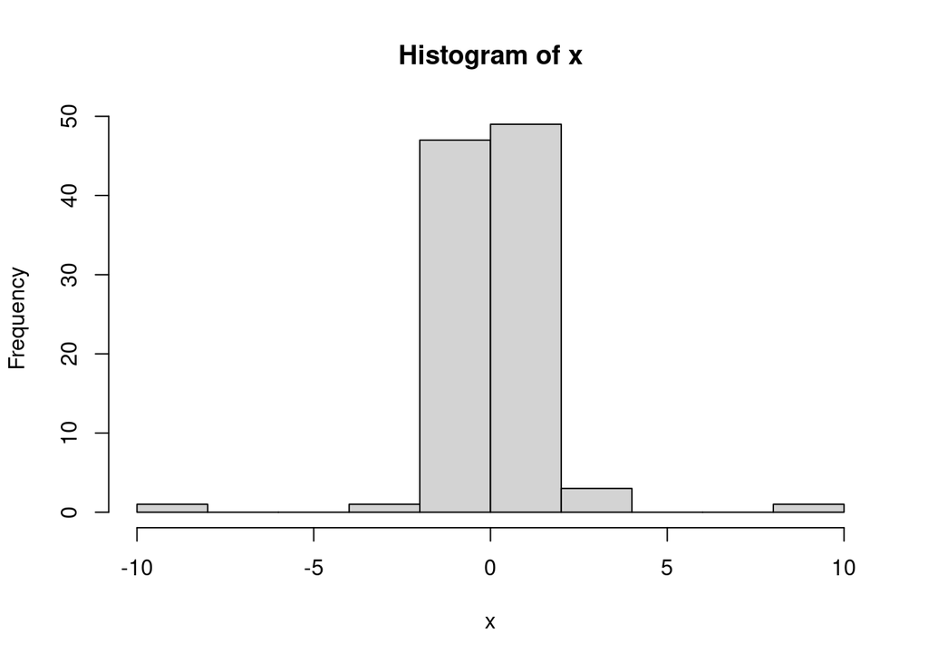

```r
set.seed(123)
x <- c(10,-10,rnorm(100))
hist(x)
```

```r
#defino los límites superior e inferior
lim_inf <- quantile(x,.25) - 1.5*IQR(x)
lim_sup <- quantile(x,.75) + 1.5*IQR(x)

x[x < lim_inf] <- NA
x[x > lim_sup] <- NA

x
```

```
  [1]           NA           NA -0.560475647 -0.230177489  1.558708314
  [6]  0.070508391  0.129287735  1.715064987  0.460916206 -1.265061235
 [11] -0.686852852 -0.445661970  1.224081797  0.359813827  0.400771451
 [16]  0.110682716 -0.555841135  1.786913137  0.497850478 -1.966617157
 [21]  0.701355902 -0.472791408 -1.067823706 -0.217974915 -1.026004448
 [26] -0.728891229 -0.625039268 -1.686693311  0.837787044  0.153373118
 [31] -1.138136937  1.253814921  0.426464221 -0.295071483  0.895125661
 [36]  0.878133488  0.821581082  0.688640254  0.553917654 -0.061911711
 [41] -0.305962664 -0.380471001 -0.694706979 -0.207917278 -1.265396352
 [46]  2.168955965  1.207961998 -1.123108583 -0.402884835 -0.466655354
 [51]  0.779965118 -0.083369066  0.253318514 -0.028546755 -0.042870457
 [56]  1.368602284 -0.225770986  1.516470604 -1.548752804  0.584613750
 [61]  0.123854244  0.215941569  0.379639483 -0.502323453 -0.333207384
 [66] -1.018575383 -1.071791226  0.303528641  0.448209779  0.053004227
 [71]  0.922267468  2.050084686 -0.491031166           NA  1.005738524
 [76] -0.709200763 -0.688008616  1.025571370 -0.284773007 -1.220717712
 [81]  0.181303480 -0.138891362  0.005764186  0.385280401 -0.370660032
 [86]  0.644376549 -0.220486562  0.331781964  1.096839013  0.435181491
 [91] -0.325931586  1.148807618  0.993503856  0.548396960  0.238731735
 [96] -0.627906076  1.360652449 -0.600259587  2.187332993  1.532610626
[101] -0.235700359 -1.026420900
```

```r
x < lim_inf
```

```
  [1]    NA    NA FALSE FALSE FALSE FALSE FALSE FALSE FALSE FALSE FALSE FALSE
 [13] FALSE FALSE FALSE FALSE FALSE FALSE FALSE FALSE FALSE FALSE FALSE FALSE
 [25] FALSE FALSE FALSE FALSE FALSE FALSE FALSE FALSE FALSE FALSE FALSE FALSE
 [37] FALSE FALSE FALSE FALSE FALSE FALSE FALSE FALSE FALSE FALSE FALSE FALSE
 [49] FALSE FALSE FALSE FALSE FALSE FALSE FALSE FALSE FALSE FALSE FALSE FALSE
 [61] FALSE FALSE FALSE FALSE FALSE FALSE FALSE FALSE FALSE FALSE FALSE FALSE
 [73] FALSE    NA FALSE FALSE FALSE FALSE FALSE FALSE FALSE FALSE FALSE FALSE
 [85] FALSE FALSE FALSE FALSE FALSE FALSE FALSE FALSE FALSE FALSE FALSE FALSE
 [97] FALSE FALSE FALSE FALSE FALSE FALSE
```

```r
x > lim_sup
```

```
  [1]    NA    NA FALSE FALSE FALSE FALSE FALSE FALSE FALSE FALSE FALSE FALSE
 [13] FALSE FALSE FALSE FALSE FALSE FALSE FALSE FALSE FALSE FALSE FALSE FALSE
 [25] FALSE FALSE FALSE FALSE FALSE FALSE FALSE FALSE FALSE FALSE FALSE FALSE
 [37] FALSE FALSE FALSE FALSE FALSE FALSE FALSE FALSE FALSE FALSE FALSE FALSE
 [49] FALSE FALSE FALSE FALSE FALSE FALSE FALSE FALSE FALSE FALSE FALSE FALSE
 [61] FALSE FALSE FALSE FALSE FALSE FALSE FALSE FALSE FALSE FALSE FALSE FALSE
 [73] FALSE    NA FALSE FALSE FALSE FALSE FALSE FALSE FALSE FALSE FALSE FALSE
 [85] FALSE FALSE FALSE FALSE FALSE FALSE FALSE FALSE FALSE FALSE FALSE FALSE
 [97] FALSE FALSE FALSE FALSE FALSE FALSE
```

```r
x[x < lim_inf | x > lim_sup] <- NA

IQR(x,na.rm = TRUE)
```

```
[1] 1.176909
```

```r
quantile(x,.25,na.rm = TRUE)
```

```
       25%
-0.4819113
```

```r
quantile(x,.75,na.rm = TRUE)
```

```
      75%
0.6949981
```

Ahora crear la función

```r
elim_anomal <- function(x,...){
  if (!is.numeric(x)) stop('suministre valor numérico')

  lim_inf <- quantile(x,.25,...) - 1.5*IQR(x,...)
  lim_sup <- quantile(x,.75,...) + 1.5*IQR(x,...)
  x[x < lim_inf | x > lim_sup] <- NA

  return(x)
}
```

- Pruebe la función con un vector numérico creado por usted.

```r
elim_anomal(x,na.rm = TRUE)
```

```
  [1]           NA           NA -0.560475647 -0.230177489  1.558708314
  [6]  0.070508391  0.129287735  1.715064987  0.460916206 -1.265061235
 [11] -0.686852852 -0.445661970  1.224081797  0.359813827  0.400771451
 [16]  0.110682716 -0.555841135  1.786913137  0.497850478 -1.966617157
 [21]  0.701355902 -0.472791408 -1.067823706 -0.217974915 -1.026004448
 [26] -0.728891229 -0.625039268 -1.686693311  0.837787044  0.153373118
 [31] -1.138136937  1.253814921  0.426464221 -0.295071483  0.895125661
 [36]  0.878133488  0.821581082  0.688640254  0.553917654 -0.061911711
 [41] -0.305962664 -0.380471001 -0.694706979 -0.207917278 -1.265396352
 [46]  2.168955965  1.207961998 -1.123108583 -0.402884835 -0.466655354
 [51]  0.779965118 -0.083369066  0.253318514 -0.028546755 -0.042870457
 [56]  1.368602284 -0.225770986  1.516470604 -1.548752804  0.584613750
 [61]  0.123854244  0.215941569  0.379639483 -0.502323453 -0.333207384
 [66] -1.018575383 -1.071791226  0.303528641  0.448209779  0.053004227
 [71]  0.922267468  2.050084686 -0.491031166           NA  1.005738524
 [76] -0.709200763 -0.688008616  1.025571370 -0.284773007 -1.220717712
 [81]  0.181303480 -0.138891362  0.005764186  0.385280401 -0.370660032
 [86]  0.644376549 -0.220486562  0.331781964  1.096839013  0.435181491
 [91] -0.325931586  1.148807618  0.993503856  0.548396960  0.238731735
 [96] -0.627906076  1.360652449 -0.600259587  2.187332993  1.532610626
[101] -0.235700359 -1.026420900
```

- Pruebe la función utilizando `mutate` con el set de datos `iris`

Utilizando una función nombrada

```r
library(dplyr)
iris |>
  mutate(across(where(is.numeric),elim_anomal)) |>
  glimpse()
```

```
Rows: 150
Columns: 5
$ Sepal.Length <dbl> 5.1, 4.9, 4.7, 4.6, 5.0, 5.4, 4.6, 5.0, 4.4, 4.9, 5.4, 4.…
$ Sepal.Width  <dbl> 3.5, 3.0, 3.2, 3.1, 3.6, 3.9, 3.4, 3.4, 2.9, 3.1, 3.7, 3.…
$ Petal.Length <dbl> 1.4, 1.4, 1.3, 1.5, 1.4, 1.7, 1.4, 1.5, 1.4, 1.5, 1.5, 1.…
$ Petal.Width  <dbl> 0.2, 0.2, 0.2, 0.2, 0.2, 0.4, 0.3, 0.2, 0.2, 0.1, 0.2, 0.…
$ Species      <fct> setosa, setosa, setosa, setosa, setosa, setosa, setosa, s…
```

- Transforme la función en una función anónima (lambda) y úsela con `mutate` con los datos `iris`

```r
iris |>
  mutate(across(where(is.numeric),.fns = function(x,...){
    lim_inf <- quantile(x,.25,...) - 1.5*IQR(x,...)
    lim_sup <- quantile(x,.75,...) + 1.5*IQR(x,...)
    x[x < lim_inf | x > lim_sup] <- NA

    return(x)
  })) |> glimpse()
```

```
Rows: 150
Columns: 5
$ Sepal.Length <dbl> 5.1, 4.9, 4.7, 4.6, 5.0, 5.4, 4.6, 5.0, 4.4, 4.9, 5.4, 4.…
$ Sepal.Width  <dbl> 3.5, 3.0, 3.2, 3.1, 3.6, 3.9, 3.4, 3.4, 2.9, 3.1, 3.7, 3.…
$ Petal.Length <dbl> 1.4, 1.4, 1.3, 1.5, 1.4, 1.7, 1.4, 1.5, 1.4, 1.5, 1.5, 1.…
$ Petal.Width  <dbl> 0.2, 0.2, 0.2, 0.2, 0.2, 0.4, 0.3, 0.2, 0.2, 0.1, 0.2, 0.…
$ Species      <fct> setosa, setosa, setosa, setosa, setosa, setosa, setosa, s…
```

- Utilice la función para eliminar valores anómalos del set de datos `agromet` en todas las variables climáticas, salvo en `grados_dias` y `horas_frio`, use la función como anónima.

```r
library(readr)
data_agro <- read_rds('../data/data_estaciones_agrometAPI.rds')

data_sinout <- data_agro |>
  select(station_id:direccion_del_viento) |>
  mutate(across(temp_promedio_aire:direccion_del_viento,.fns = elim_anomal,na.rm = TRUE))

data_sinout |> glimpse()
```

```
Rows: 3,573,024
Columns: 11
$ station_id            <dbl> 1, 1, 1, 1, 1, 1, 1, 1, 1, 1, 1, 1, 1, 1, 1, 1, …
$ fecha_hora            <dttm> 2021-01-01 03:00:00, 2021-01-01 04:00:00, 2021-…
$ temp_promedio_aire    <dbl> 20.4, 20.4, 20.4, 20.4, NA, 22.8, 24.0, 25.2, 25…
$ precipitacion_horaria <dbl> 0, 0, 0, 0, NA, 0, 0, 0, 0, 0, 0, 0, 0, 0, 0, 0,…
$ humed_rel_promedio    <dbl> 66.0, 66.0, 66.0, 66.0, NA, 59.0, 56.2, 52.8, 49…
$ presion_atmosferica   <dbl> 1012.0, 1012.1, 1012.5, 1013.0, NA, 1013.5, 1013…
$ radiacion_solar_max   <dbl> 0, 0, 0, 0, NA, 299, 740, 867, 932, NA, NA, 939,…
$ veloc_max_viento      <dbl> 0.0, 0.0, 0.0, 0.0, NA, 0.4, 3.1, 3.6, 3.1, 3.1,…
$ temp_minima           <dbl> 20.4, 20.4, 20.4, 20.4, NA, 22.2, 23.2, 24.7, 25…
$ temp_maxima           <dbl> 20.4, 20.4, 20.4, 20.4, NA, 23.1, 24.6, 25.6, 25…
$ direccion_del_viento  <dbl> 250, 250, 250, 250, NA, 259, 276, 291, 331, 330,…
```

### 1.2 Función para `{dplyr}` (ej., `mutate`) con multiples columnas como argumentos (30 pts)

- Utilizando el set de datos `iris` y `mutate` haga el calculo en que cada columna numérica sea dividida por la raiz cuadrada de el promedio de `Sepal.Lenght`.

```r
val <- sqrt(mean(iris$Sepal.Length))
iris |>
  mutate(SL = Sepal.Length/ val,
         SW = Sepal.Width/ val,
         PL = Petal.Length/ val,
         PW = Petal.Width/ val) |>
  glimpse()
```

```
Rows: 150
Columns: 9
$ Sepal.Length <dbl> 5.1, 4.9, 4.7, 4.6, 5.0, 5.4, 4.6, 5.0, 4.4, 4.9, 5.4, 4.…
$ Sepal.Width  <dbl> 3.5, 3.0, 3.2, 3.1, 3.6, 3.9, 3.4, 3.4, 2.9, 3.1, 3.7, 3.…
$ Petal.Length <dbl> 1.4, 1.4, 1.3, 1.5, 1.4, 1.7, 1.4, 1.5, 1.4, 1.5, 1.5, 1.…
$ Petal.Width  <dbl> 0.2, 0.2, 0.2, 0.2, 0.2, 0.4, 0.3, 0.2, 0.2, 0.1, 0.2, 0.…
$ Species      <fct> setosa, setosa, setosa, setosa, setosa, setosa, setosa, s…
$ SL           <dbl> 2.109793, 2.027056, 1.944319, 1.902951, 2.068425, 2.23389…
$ SW           <dbl> 1.447897, 1.241055, 1.323792, 1.282423, 1.489266, 1.61337…
$ PL           <dbl> 0.5791589, 0.5791589, 0.5377904, 0.6205274, 0.5791589, 0.…
$ PW           <dbl> 0.08273698, 0.08273698, 0.08273698, 0.08273698, 0.0827369…
```

- Utilice `across` y `mutate` junto con una función anónima (lambda)

```r
iris |>
  mutate(across(where(is.numeric),\(x,y) x/sqrt(mean(y)),y=Sepal.Length)) |>
  glimpse()
```

```
Rows: 150
Columns: 5
$ Sepal.Length <dbl> 2.109793, 2.027056, 1.944319, 1.902951, 2.068425, 2.23389…
$ Sepal.Width  <dbl> 1.447897, 1.241055, 1.323792, 1.282423, 1.489266, 1.61337…
$ Petal.Length <dbl> 0.5791589, 0.5791589, 0.5377904, 0.6205274, 0.5791589, 0.…
$ Petal.Width  <dbl> 0.08273698, 0.08273698, 0.08273698, 0.08273698, 0.0827369…
$ Species      <fct> setosa, setosa, setosa, setosa, setosa, setosa, setosa, s…
```

- Utilice `across` y `mutate` junto con una función nombrada (lambda)

```r
fun <- function(x,y) x/sqrt(mean(y))

iris |>
  mutate(across(where(is.numeric),.fns = fun,y=Sepal.Length)) |>
  glimpse()
```

```
Rows: 150
Columns: 5
$ Sepal.Length <dbl> 2.109793, 2.027056, 1.944319, 1.902951, 2.068425, 2.23389…
$ Sepal.Width  <dbl> 1.447897, 1.241055, 1.323792, 1.282423, 1.489266, 1.61337…
$ Petal.Length <dbl> 0.5791589, 0.5791589, 0.5377904, 0.6205274, 0.5791589, 0.…
$ Petal.Width  <dbl> 0.08273698, 0.08273698, 0.08273698, 0.08273698, 0.0827369…
$ Species      <fct> setosa, setosa, setosa, setosa, setosa, setosa, setosa, s…
```

### 1.3 Resumir por rangos tipo categórica (50pts)

- Cree una función que identifique tres grupos para un vector numérico `x`, alto, medio y bajo. Use la función `cut` y rangos de igual tamaño

```r
fun2 <- function(x) cut(x,3,labels = c('alto','medio','bajo'))
```

- Pruebe la función con un vector numérico creado por usted.

```r
fun2(1:10)
```

```
 [1] alto  alto  alto  alto  medio medio medio bajo  bajo  bajo
Levels: alto medio bajo
```

- Pruebe la función utilizando `mutate` con el set de datos `iris`

```r
iris |>
  mutate(across(where(is.numeric),fun2)) |>
  glimpse()
```

```
Rows: 150
Columns: 5
$ Sepal.Length <fct> alto, alto, alto, alto, alto, alto, alto, alto, alto, alt…
$ Sepal.Width  <fct> medio, medio, medio, medio, medio, bajo, medio, medio, me…
$ Petal.Length <fct> alto, alto, alto, alto, alto, alto, alto, alto, alto, alt…
$ Petal.Width  <fct> alto, alto, alto, alto, alto, alto, alto, alto, alto, alt…
$ Species      <fct> setosa, setosa, setosa, setosa, setosa, setosa, setosa, s…
```

- Transforme la función en una función anónima (lambda) y úsela con `mutate` con los datos `iris`

```r
iris |>
  mutate(across(where(is.numeric),\(x) cut(x,3,labels = c('alto','medio','bajo')))) |>
  glimpse()
```

```
Rows: 150
Columns: 5
$ Sepal.Length <fct> alto, alto, alto, alto, alto, alto, alto, alto, alto, alt…
$ Sepal.Width  <fct> medio, medio, medio, medio, medio, bajo, medio, medio, me…
$ Petal.Length <fct> alto, alto, alto, alto, alto, alto, alto, alto, alto, alt…
$ Petal.Width  <fct> alto, alto, alto, alto, alto, alto, alto, alto, alto, alt…
$ Species      <fct> setosa, setosa, setosa, setosa, setosa, setosa, setosa, s…
```

- Utilice la función para clasificar los set de datos `agromet` en todas las variables climáticas, salvo en `grados_dias` y `horas_frio`, use la función como anónima.

```r
data_agro |>
  select(station_id:direccion_del_viento) |>
  mutate(station_id = as.factor(station_id)) |>
  mutate(across(where(is.numeric),\(x) cut(x,3,labels = c('alto','medio','bajo'))))
```

```
# A tibble: 3,573,024 × 11
   station…¹ fecha_hora          temp_…² preci…³ humed…⁴ presi…⁵ radia…⁶ veloc…⁷
   <fct>     <dttm>              <fct>   <fct>   <fct>   <fct>   <fct>   <fct>
 1 1         2021-01-01 03:00:00 medio   alto    alto    bajo    alto    alto
 2 1         2021-01-01 04:00:00 medio   alto    alto    bajo    alto    alto
 3 1         2021-01-01 05:00:00 medio   alto    alto    bajo    alto    alto
 4 1         2021-01-01 06:00:00 medio   alto    alto    bajo    alto    alto
 5 1         2021-01-01 07:00:00 <NA>    <NA>    <NA>    <NA>    <NA>    <NA>
 6 1         2021-01-01 08:00:00 medio   alto    alto    bajo    alto    alto
 7 1         2021-01-01 09:00:00 medio   alto    alto    bajo    medio   alto
 8 1         2021-01-01 10:00:00 medio   alto    alto    bajo    medio   alto
 9 1         2021-01-01 11:00:00 medio   alto    alto    bajo    medio   alto
10 1         2021-01-01 12:00:00 medio   alto    alto    bajo    medio   alto
# … with 3,573,014 more rows, 3 more variables: temp_minima <fct>,
#   temp_maxima <fct>, direccion_del_viento <fct>, and abbreviated variable
#   names ¹station_id, ²temp_promedio_aire, ³precipitacion_horaria,
#   ⁴humed_rel_promedio, ⁵presion_atmosferica, ⁶radiacion_solar_max,
#   ⁷veloc_max_viento
```

### 1.4 Coeficiente de variación (50pts)

- Cree una función que permita seleccionar las variables numéricas cuyos valores son menores a un coeficiente de variación (CV) de 0.3 (30%).

$$CV = \frac{\sigma}{\bar{x}}$$

```r
sel_cv <- function(x) {
  x <- na.omit(x)
  out <- FALSE
  if (is.numeric(x)){
    cv <- sd(x)/mean(x)
    out <- cv < 0.3
    }

  return(isTRUE(out))

}
```

- Cree una función nombrada y apliquela a un vector aleatorio.

```r
set.seed(345)
sel_cv(rnorm(100))
```

```
[1] TRUE
```

```r
sel_cv(runif(100))
```

```
[1] FALSE
```

- Aplique la función con `apply` a las columnas numéricas del set de datos `iris`

```r
iris[,1:4] |>
  apply(2,sel_cv)
```

```
Sepal.Length  Sepal.Width Petal.Length  Petal.Width
        TRUE         TRUE        FALSE        FALSE
```

- Aplique la función con `where` para seleccionar columnas del set de datos `iris`

```r
iris |>
  select(where(sel_cv)) |>
  glimpse()
```

```
Rows: 150
Columns: 2
$ Sepal.Length <dbl> 5.1, 4.9, 4.7, 4.6, 5.0, 5.4, 4.6, 5.0, 4.4, 4.9, 5.4, 4.…
$ Sepal.Width  <dbl> 3.5, 3.0, 3.2, 3.1, 3.6, 3.9, 3.4, 3.4, 2.9, 3.1, 3.7, 3.…
```

- Aplique la función al set de datos agromet en el que se filtraron los valores anómalos.

```r
data_sinout |>
  select(1:4) |>
  select(where(sel_cv)) |>
  glimpse()
```

```
Rows: 3,573,024
Columns: 0
```

## 2 Ejercicios transformación y visualización

### 2.1 Comparar distribuciones (40pts)

- Compare las distribuciones de datos con y sin los valores anómalos obtenidas en el ejercicio 1.1. Agrúpe las estaciones por región de Chile.

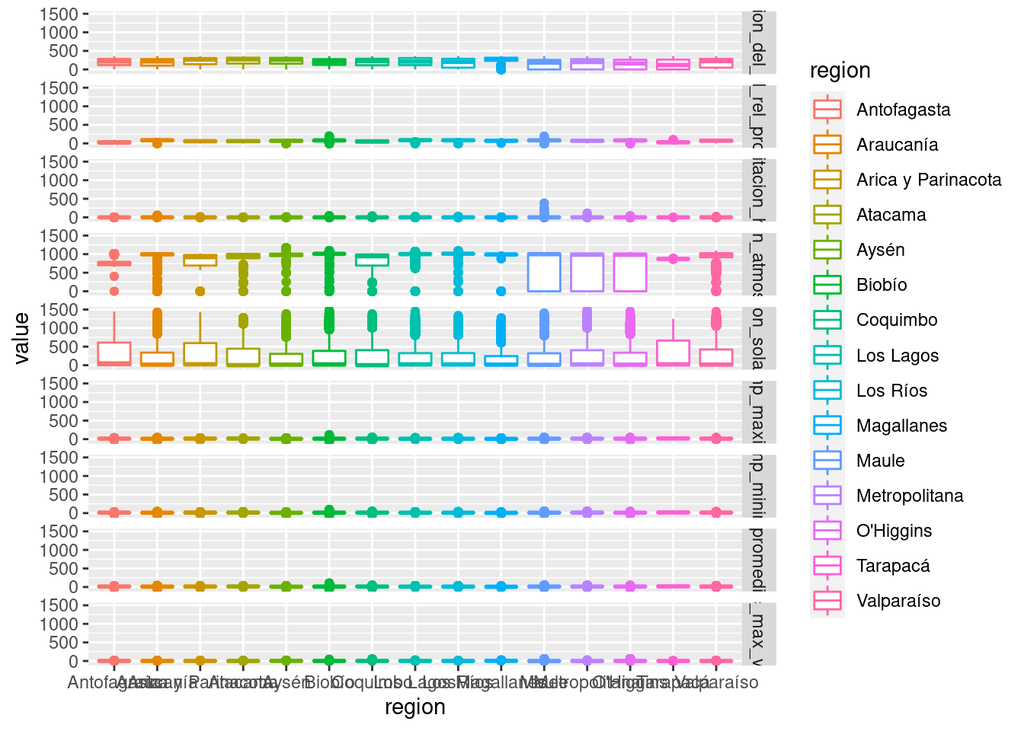

```r
library(tidyr)
library(ggplot2)
metadata <- read_rds('../data/metadata_estaciones_agrometAPI.rds')

#sin filtrar

data_sf <- data_agro |>
    select(station_id:direccion_del_viento) |>  pivot_longer(temp_promedio_aire:direccion_del_viento)

#data con filtrar
data_cf <- data_agro |>
  select(station_id:direccion_del_viento) |>
  mutate(across(temp_promedio_aire:direccion_del_viento,.fns = elim_anomal,na.rm = TRUE)) |>
  pivot_longer(temp_promedio_aire:direccion_del_viento,values_to = 'value_fil')


data_join <- left_join(data_sf,data_cf) |>
  left_join(metadata, by = c('station_id' = 'ema'))
  ggplot(data_join,aes(region,value,colour = region)) +
    geom_boxplot() +
    facet_grid(name~.)
```

```r
    theme_bw()
```

[output not shown]

[output cut: 365 more lines]

[output not shown]

- Cree un gráfico para visualizar la densidad de distribución de la precipitación acumulada diaria para las diferentes regiones de Chile. Use gráfico de `densidad` (`geom_density`)

### 2.2 Valores anómalos

- Visualice la cantidad de NAs implicitos diarios por estación para todas las variables de los datos `agromet`. Utilice gráficos de tipo heatmap (`geom_tile`).
- Visualice la cantidad de NAs implicitos diarios por sesnor y profundidad para todas las variables del set de datos ordenados de `agv`. Utilice gráficos de tipo heatmap (`geom_tile`).

### 2.3 Variación variables (60pts)

- Visualice la variación de la temperatura media diaria para todo Chile. Use tipo de gráfico `boxplot` (`geom_boxplot`).
- Cree un gráfico en ggplot para visualizar la variación de la temperatura media mensual para las diferentes regiones de Chile. Use tipo de gráfico `scatterplot` (`geom_point`) con barra de error (`geom_error_bar`).
- Cree una visualización para la variación latitudinal de la radiación solar mensual para el año 2021 a lo largo de Chile. Use tipo de gráfico `scatterplot` (`geom_point`) con barra de error (`geom_error_bar`).